# Code Portfolio

Weijian Zhang

April 13, 2019

Github Link: https://github.com/wzhang8-harrisburg/ANLY506/tree/master/Final_Report

## 1. Questions to answer

This report is going to identify difference among demographic regions and find out the development of difference over time.  
According to the data provided, this report will focus on three dimensions: population, income and life expectance.

## 2. Dataset summary

The dataset: gapminder contains 41,284 observatioins with 6 variables. And the first few observations is sown as below:

```r
gapminder <- read_csv("../Data/gapminder.csv")
head(gapminder)
```

```
## # A tibble: 6 x 6
##   Country      Year  life population income region
##   <chr>       <int> <dbl>      <dbl>  <dbl> <chr>
## 1 Afghanistan  1800  28.2    3280000    603 South Asia
## 2 Afghanistan  1801  28.2         NA    603 South Asia
## 3 Afghanistan  1802  28.2         NA    603 South Asia
## 4 Afghanistan  1803  28.2         NA    603 South Asia
## 5 Afghanistan  1804  28.2         NA    603 South Asia
## 6 Afghanistan  1805  28.2         NA    603 South Asia
```

```r
str(gapminder)
```

```
## Classes 'tbl_df', 'tbl' and 'data.frame':    41284 obs. of  6 variables:
##  $ Country   : chr  "Afghanistan" "Afghanistan" "Afghanistan" "Afghanistan" ...
##  $ Year      : int  1800 1801 1802 1803 1804 1805 1806 1807 1808 1809 ...
##  $ life      : num  28.2 28.2 28.2 28.2 28.2 ...
##  $ population: num  3280000 NA NA NA NA NA NA NA NA NA ...
##  $ income    : num  603 603 603 603 603 603 603 603 603 603 ...
##  $ region    : chr  "South Asia" "South Asia" "South Asia" "South Asia" ...
##  - attr(*, "spec")=List of 2
##   ..$ cols   :List of 6
##   .. ..$ Country   : list()
##   .. .. ..- attr(*, "class")= chr  "collector_character" "collector"
##   .. ..$ Year      : list()
##   .. .. ..- attr(*, "class")= chr  "collector_integer" "collector"
##   .. ..$ life      : list()
##   .. .. ..- attr(*, "class")= chr  "collector_double" "collector"
##   .. ..$ population: list()
##   .. .. ..- attr(*, "class")= chr  "collector_number" "collector"
##   .. ..$ income    : list()
##   .. .. ..- attr(*, "class")= chr  "collector_double" "collector"
##   .. ..$ region    : list()
##   .. .. ..- attr(*, "class")= chr  "collector_character" "collector"
##   ..$ default: list()
##   .. ..- attr(*, "class")= chr  "collector_guess" "collector"
##   ..- attr(*, "class")= chr "col_spec"
```

```r
# amount of unique value in country column
length(unique(gapminder$Country))
```

```
## [1] 197
```

```r
# amount of unique value in year column
length(unique(gapminder$Year))
```

```
## [1] 216
```

```r
# amount of unique value in region column
length(unique(gapminder$region))
```

```
## [1] 6
```

```r
# list all value in region column
unique(gapminder$region)
```

```
## [1] "South Asia"                 "Europe & Central Asia"
## [3] "Middle East & North Africa" "Sub-Saharan Africa"
## [5] "America"                    "East Asia & Pacific"
```

Within the dataset, data from 197 conturies are including and time range overall is 216 years. Besides, all coutnries are further classified into 6 regions.

## 3. Dataset cleaning

From the above summary, invalid values were spotted in the previous step.  
It is important to clear invalid values from the dataset to reach a meaningful conslusion.

```r
# count missing value by columns
colSums(is.na(gapminder))
```

```
##    Country       Year       life population     income     region
##          0          0          0      25817       2341          0
```

There are missing values in both column population and income

```r
# remove missing values
gapminder_cleaned <- na.omit(gapminder)
```

```r
# check the new dataset, with NAs removed
head(gapminder_cleaned)
```

```
## # A tibble: 6 x 6
##   Country      Year  life population income region
##   <chr>       <int> <dbl>      <dbl>  <dbl> <chr>
## 1 Afghanistan  1800  28.2    3280000    603 South Asia
## 2 Afghanistan  1810  28.1    3280000    604 South Asia
## 3 Afghanistan  1820  28.0    3323519    604 South Asia
## 4 Afghanistan  1830  27.9    3448982    625 South Asia
## 5 Afghanistan  1840  27.8    3625022    647 South Asia
## 6 Afghanistan  1850  27.7    3810047    669 South Asia
```

```r
# check if any missing value remains
colSums(is.na(gapminder_cleaned))
```

```
##    Country       Year       life population     income     region
##          0          0          0          0          0          0
```

There is no more missing values within the dataset.

## 4. Analysis

### 4.1 Life expectance

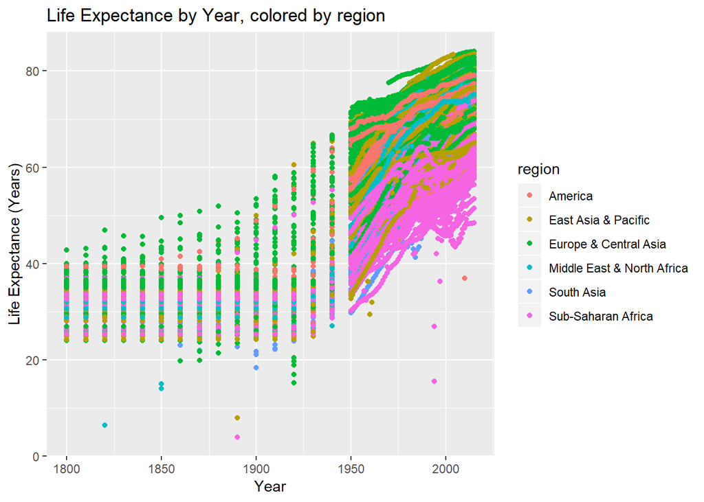

```r
ggplot(gapminder_cleaned, aes(x = Year, y = life, group = Country)) +
  geom_point(aes(color = region)) +
  ggtitle("Life Expectance by Year, colored by region") + xlab("Year") + ylab("Life Expectance (Years)")
```

There are 197 countries in the dataset, it is impossible to put in legend for the above plot. From the above plot, it is easy to conclude people are having significantly higher life expectance now than it was 200 years ago. Another interesting finding is that, in 1800 and 2000, the gap between countries are less than the gap in 1950. One of the possible reason is that, during 50s, some countries have signifcant development in income and technology; and it takes couple decades for such technology to spread all over the world. Therefore, the gap of life expectance among countries is narrowing.

However, there are too many countries, and the plot is not big enough.

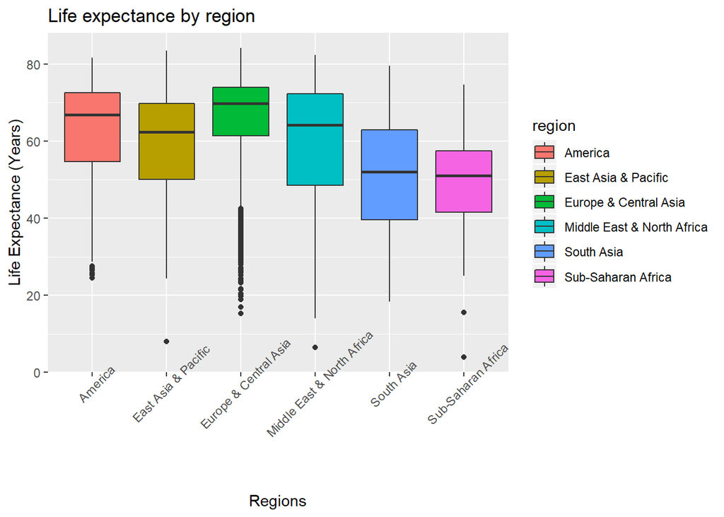

```r
ggplot(gapminder_cleaned, aes(x = region, y = life, fill = region)) +
  geom_boxplot() +
  theme(axis.text.x = element_text(angle = 45)) +
  ggtitle("Life expectance by region") + xlab("Regions") + ylab("Life Expectance (Years)")
```

From the above boxplot, Europe & Central Asia is having the highest life expectance in the overall time span, and South Asia and Sub-Saharan Africa are having the lowest life expectance. However, South Asia has a wider box, which mean the difference among countries are having difference life expectance.

### 4.2 Population

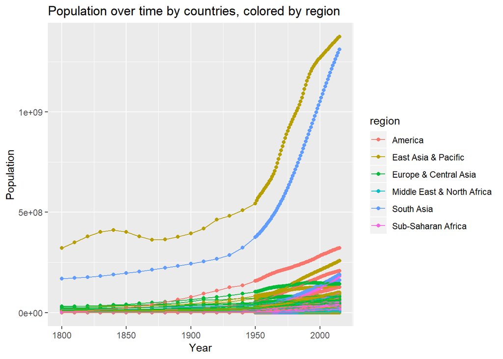

```r
ggplot(gapminder_cleaned, aes(x = Year, y = population, group = Country)) +
  geom_point(aes(color = region)) +
  geom_line(aes(color = region)) +
  ggtitle("Population over time by countries, colored by region") + xlab("Year") + ylab("Population")
```

There are 197 countries in the dataset, it is impossible to put in legend for the above plot. The slope on the plot shows before 1950, global population was growing steadly. After 1950, population was growing faster for most of countries, especially for top 3 countries by popluation.

At the same time, the country with largest population is always the largest in population throught out the whole period of dataset. So does the seond place, and it is correct for most of time for third place. Therefore, running a sort on population of the last year in the dataset can show top countries with population. To find out top countries in population:

```r
# subset data
yearSubset = subset(gapminder_cleaned, Year == max(gapminder_cleaned$Year))
```

```r
# sort data by population
head(yearSubset[order(-yearSubset$population), ])
```

```
## # A tibble: 6 x 6
##   Country        Year  life population income region
##   <chr>         <int> <dbl>      <dbl>  <dbl> <chr>
## 1 China          2015  76.9 1376048943  13334 East Asia & Pacific
## 2 India          2015  66.8 1311050527   5903 South Asia
## 3 United States  2015  79.1  321773631  53354 America
## 4 Indonesia      2015  70.9  257563815  10504 East Asia & Pacific
## 5 Brazil         2015  75.6  207847528  15441 America
## 6 Pakistan       2015  66.5  188924874   4743 South Asia
```

From the table above, China, India and United States were having most popluation in the world. And their population were growing faster than any other countries.

### 4.3 Income

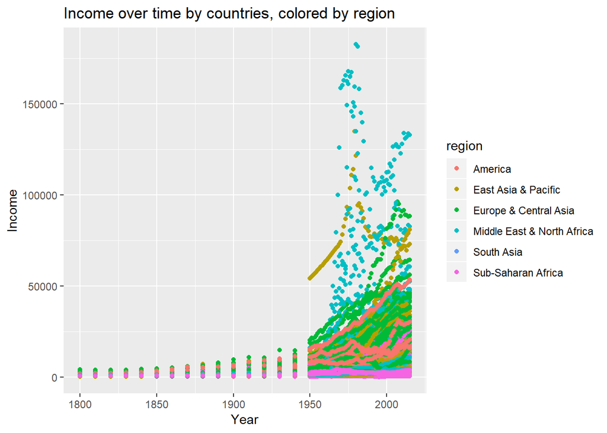

```r
ggplot(gapminder_cleaned, aes(x = Year, y = income, group = Country)) +
  geom_point(aes(color = region)) +
  ggtitle("Income over time by countries, colored by region") + xlab("Year") + ylab("Income")
```

There are 197 countries in the dataset, it is impossible to put in legend for the above plot. However, from the above plot, it can be found that East Asia & Pacific was having huge income boost. And it looks like one country was growing extremely fast from 1950 to 1975, but its income droped after its peak. While another country was keep growing in its income, however in a slower pace than the above mentioned country. But, since there are too many countries in this plot. We need a subset of data to see if all previous founding is true; and if it is true, which two countries were making miracle.

```r
# Subseting East Asia & Pacific Regioin
regionSubset = subset(gapminder_cleaned, region == "East Asia & Pacific")
# amount of countries in this region
length(unique(regionSubset$Country))
```

```
## [1] 27
```

```r
# count missing value by columns
colSums(is.na(regionSubset))
```

```
##    Country       Year       life population     income     region
##          0          0          0          0          0          0
```

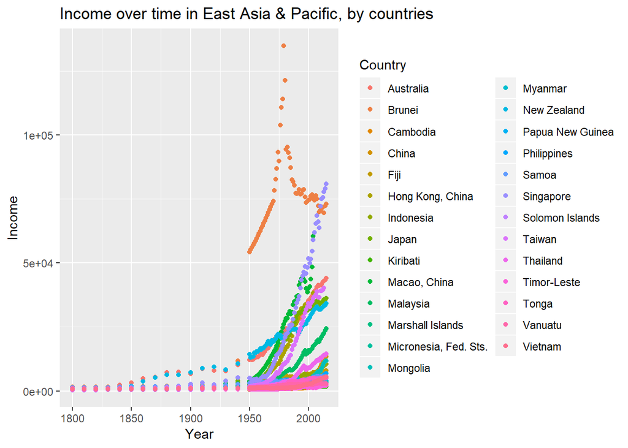

```r
ggplot(regionSubset, aes(x = Year, y = income, group = Country)) +
  geom_point(aes(color = Country)) +
  ggtitle("Income over time in East Asia & Pacific, by countries") + xlab("Year") + ylab("Income")
```

From the plot above, the previous assumption was proved and those two patent belong two countries respectively.

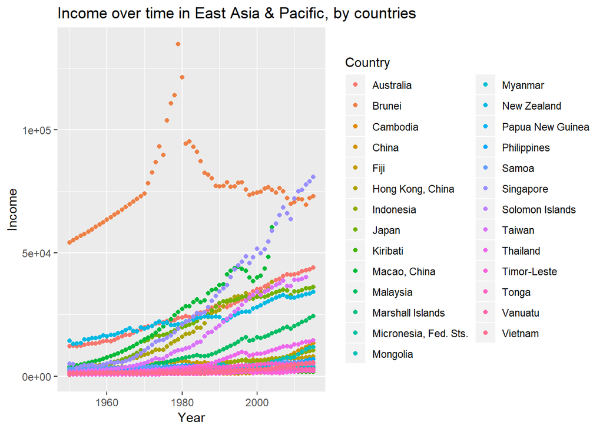

```r
ggplot(regionSubset, aes(x = Year, y = income, group = Country)) +
  geom_point(aes(color = Country)) +
  ggtitle("Income over time in East Asia & Pacific, by countries") + xlab("Year") + ylab("Income") +
  xlim(1950, max(gapminder_cleaned$Year))
```

From the plot above, the patent of income growth for different coutries are more significant.

```r
# sort data by income in 2015
regionSubset_2015 = subset(regionSubset, Year == 2015)
top10CountryList <- regionSubset_2015[order(-regionSubset_2015$income), ]$Country[1:10]
```

```r
# region subset by country
regionSubset_Country = subset(regionSubset, Country %in% top10CountryList)
```

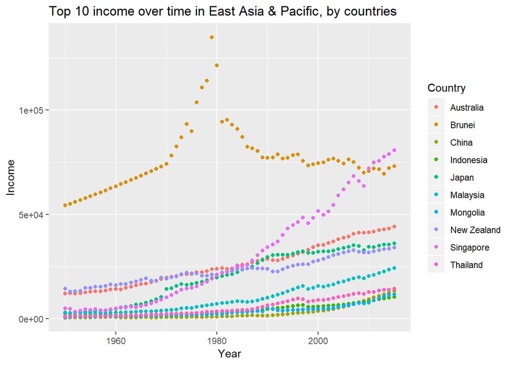

```r
ggplot(regionSubset_Country, aes(x = Year, y = income, group = Country)) +
  geom_point(aes(color = Country)) +
  ggtitle("Top 10 income over time in East Asia & Pacific, by countries") + xlab("Year") + ylab("Income") +
  xlim(1950, max(gapminder_cleaned$Year))
```